# Carseats- Regresión lineal - Basic example

*1.* La librería ISLR de R (cuya documentación puedes ver aquí) te permite cargar el set de datos Carseats.

```r
library(ISLR)
```

Sales of Child Car Seats

A simulated data set containing sales of child car seats at 400 different stores.

A data frame with 400 observations on the following 11 variables.

- Sales: Unit sales (in thousands) at each location
- CompPrice: Price charged by competitor at each location
- Income: Community income level (in thousands of dollars)
- Advertising: Local advertising budget for company at each location (in thousands of dollars)
- Population: Population size in region (in thousands)
- Price: Price company charges for car seats at each site
- ShelveLoc: A factor with levels Bad, Good and Medium indicating the quality of the shelving location for the car seats at each site
- Age: Average age of the local population
- Education: Education level at each location
- Urban: A factor with levels No and Yes to indicate whether the store is in an urban or rural location
- US: A factor with levels No and Yes to indicate whether the store is in the US or not

```r
library(data.table)
Carseats <- as.data.table(Carseats)
attach(Carseats)
str(Carseats)
```

```
## Classes 'data.table' and 'data.frame':   400 obs. of  11 variables:
##  $ Sales      : num  9.5 11.22 10.06 7.4 4.15 ...
##  $ CompPrice  : num  138 111 113 117 141 124 115 136 132 132 ...
##  $ Income     : num  73 48 35 100 64 113 105 81 110 113 ...
##  $ Advertising: num  11 16 10 4 3 13 0 15 0 0 ...
##  $ Population : num  276 260 269 466 340 501 45 425 108 131 ...
##  $ Price      : num  120 83 80 97 128 72 108 120 124 124 ...
##  $ ShelveLoc  : Factor w/ 3 levels "Bad","Good","Medium": 1 2 3 3 1 1 3 2 3 3 ...
##  $ Age        : num  42 65 59 55 38 78 71 67 76 76 ...
##  $ Education  : num  17 10 12 14 13 16 15 10 10 17 ...
##  $ Urban      : Factor w/ 2 levels "No","Yes": 2 2 2 2 2 1 2 2 1 1 ...
##  $ US         : Factor w/ 2 levels "No","Yes": 2 2 2 2 1 2 1 2 1 2 ...
##  - attr(*, ".internal.selfref")=<externalptr>
```

Responde a las siguientes cuestiones:

**a)** Ajusta un modelo de regresión lineal para predecir Sales usando Price, Urban y US.

```r
modelPUUS <- lm(Sales ~ Price + Urban + US)
summary(modelPUUS)
```

```
##
## Call:
## lm(formula = Sales ~ Price + Urban + US)
##
## Residuals:
##     Min      1Q  Median      3Q     Max
## -6.9206 -1.6220 -0.0564  1.5786  7.0581
##
## Coefficients:
##              Estimate Std. Error t value Pr(>|t|)
## (Intercept) 13.043469   0.651012  20.036  < 2e-16 ***
## Price       -0.054459   0.005242 -10.389  < 2e-16 ***
## UrbanYes    -0.021916   0.271650  -0.081    0.936
## USYes        1.200573   0.259042   4.635 4.86e-06 ***
## ---
## Signif. codes:  0 '***' 0.001 '**' 0.01 '*' 0.05 '.' 0.1 ' ' 1
##
## Residual standard error: 2.472 on 396 degrees of freedom
## Multiple R-squared:  0.2393, Adjusted R-squared:  0.2335
## F-statistic: 41.52 on 3 and 396 DF,  p-value: < 2.2e-16
```

**b)** Interpreta los coeficientes del modelo y descríbelo en forma de ecuación.

Los coeficientes de los predictores son:

```r
coef <- modelPUUS$coefficients
```

Que determinan la ecuación de ajuste:

`Sales =` -0.0544588 `*Price` -0.0219162 `*Urban +` 1.2005727 `*US +` 13.0434689

El hecho de que los coeficientes relacionados con `Price` y la variable `Urban` sean negativos indica que a mayor precio menor número de ventas y que si el almacen es urbano las ventas son inferiores que si se trata de un almacen rural. Por otro lado `US` lleva un peso positivo, de manera que si el almacen está en Estados Unidos mayores son las ventas.

Los pesos relativos se pueden calcular según:

```r
abs(coef/min(abs(coef)))
```

```
## (Intercept)       Price    UrbanYes       USYes
##  595.153275    2.484873    1.000000   54.780272
```

**c)** ¿Cuáles de los predictores tienen una relación estadísticamente significativa con la variable respuesta? En base a esto, construye un modelo reducido que sólo emplee esos predictores, y compara su bondad de ajuste con el modelo anterior.

```r
summary(modelPUUS)
```

```
##
## Call:
## lm(formula = Sales ~ Price + Urban + US)
##
## Residuals:
##     Min      1Q  Median      3Q     Max
## -6.9206 -1.6220 -0.0564  1.5786  7.0581
##
## Coefficients:
##              Estimate Std. Error t value Pr(>|t|)
## (Intercept) 13.043469   0.651012  20.036  < 2e-16 ***
## Price       -0.054459   0.005242 -10.389  < 2e-16 ***
## UrbanYes    -0.021916   0.271650  -0.081    0.936
## USYes        1.200573   0.259042   4.635 4.86e-06 ***
## ---
## Signif. codes:  0 '***' 0.001 '**' 0.01 '*' 0.05 '.' 0.1 ' ' 1
##
## Residual standard error: 2.472 on 396 degrees of freedom
## Multiple R-squared:  0.2393, Adjusted R-squared:  0.2335
## F-statistic: 41.52 on 3 and 396 DF,  p-value: < 2.2e-16
```

Observando el *p-valor* de los coeficientes, la variable `Urban` no es significativa, en este caso `Pr(>|t|) = 0.936`, que es muy grande. `Price`y `US` tienen *p-valores* muy pequeños, con significancias inferiores al 0.1%.

Construimos el nuevo modelo sin `Urban`

```r
modelPUS <- lm(Sales ~ Price + US)
summary(modelPUS)
```

```
##
## Call:
## lm(formula = Sales ~ Price + US)
##
## Residuals:
##     Min      1Q  Median      3Q     Max
## -6.9269 -1.6286 -0.0574  1.5766  7.0515
##
## Coefficients:
##             Estimate Std. Error t value Pr(>|t|)
## (Intercept) 13.03079    0.63098  20.652  < 2e-16 ***
## Price       -0.05448    0.00523 -10.416  < 2e-16 ***
## USYes        1.19964    0.25846   4.641 4.71e-06 ***
## ---
## Signif. codes:  0 '***' 0.001 '**' 0.01 '*' 0.05 '.' 0.1 ' ' 1
##
## Residual standard error: 2.469 on 397 degrees of freedom
## Multiple R-squared:  0.2393, Adjusted R-squared:  0.2354
## F-statistic: 62.43 on 2 and 397 DF,  p-value: < 2.2e-16
```

**d)** Estudia la existencia de outliers o high leverage points en este último modelo.

Pintamos los residuos

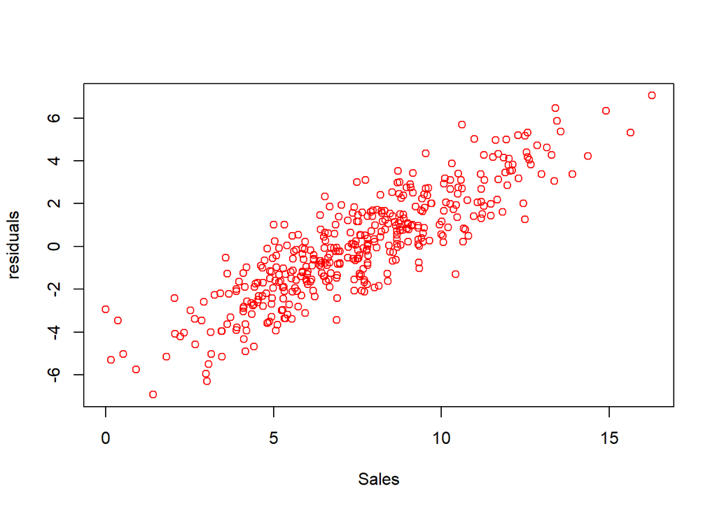

```r
plot(Sales, modelPUS$residuals, col = 'red', xlab = 'Sales', ylab = 'residuals')
```

```r
summary(modelPUS$residuals)
```

```
##    Min. 1st Qu.  Median    Mean 3rd Qu.    Max.
## -6.9269 -1.6286 -0.0574  0.0000  1.5766  7.0515
```

En general no es un modelo espectacular, el error tiene una relación lineal con la variable objetivo, es mejorable quizá incorporando nuevos predictores (no se hará aquí). El rango de valores que toman los residuos es grande, respecto a su valor medio de cero. Utilizaremos el diagrama de *caja y bigotes* para disinguir los outliers. Seguimos el criterio de que un punto pertenece a los `outliers` si se separa de la caja más de 1.5 veces el rango intercuartílico, definido como $RIC = Q3 - Q1$. Recordemos que la caja se centra en la mediana, y su límite inferior es el cuartil $Q1$ y el superior el cuartil $Q3$.

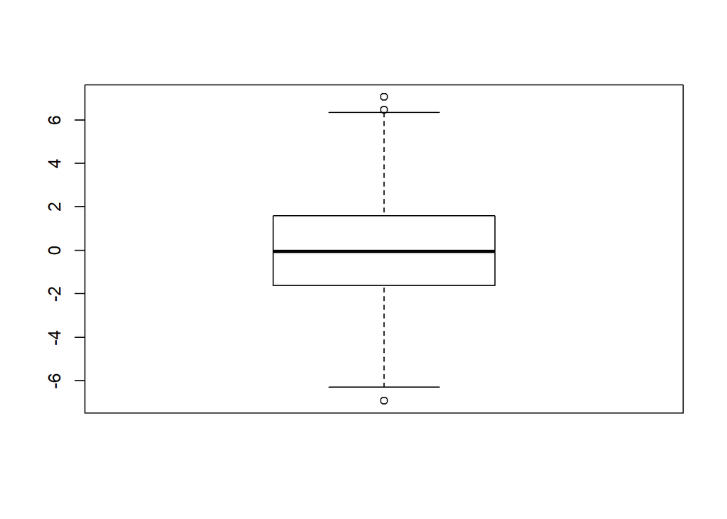

```r
outliers <- boxplot(modelPUS$residuals)$out
```

```r
outliers
```

```
##        51        69       377
## -6.926851  6.459567  7.051506
```

Esos tres puntos se pueden ver como outliers. Si los eliminamos:

```r
modelPUSNO <- lm(Sales ~ Price + US, data = Carseats[-as.numeric(names(outliers))])
summary(modelPUSNO)
```

```
##
## Call:
## lm(formula = Sales ~ Price + US, data = Carseats[-as.numeric(names(outliers))])
##
## Residuals:
##     Min      1Q  Median      3Q     Max
## -6.2812 -1.6103 -0.0493  1.5744  6.3368
##
## Coefficients:
##              Estimate Std. Error t value Pr(>|t|)
## (Intercept) 13.029095   0.616063  21.149  < 2e-16 ***
## Price       -0.054463   0.005108 -10.663  < 2e-16 ***
## USYes        1.173779   0.252396   4.651 4.53e-06 ***
## ---
## Signif. codes:  0 '***' 0.001 '**' 0.01 '*' 0.05 '.' 0.1 ' ' 1
##
## Residual standard error: 2.406 on 394 degrees of freedom
## Multiple R-squared:  0.248,  Adjusted R-squared:  0.2441
## F-statistic: 64.95 on 2 and 394 DF,  p-value: < 2.2e-16
```

Los coeficientes no cambian demasiado pero la bondad de ajuste sube del 23.54% al 24.41%

La existencia de puntos de palanca (*high leverage points*) se puede explorar en la gráfica siguiente:

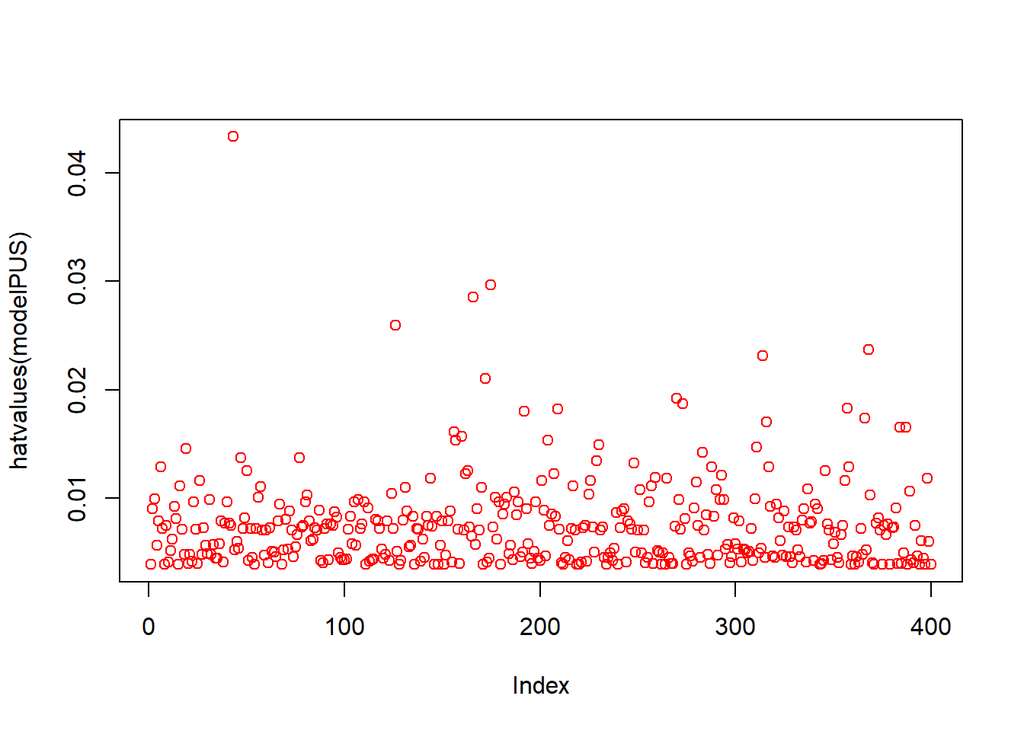

```r
plot(hatvalues(modelPUS), col = 'red')
```

```r
str(hatvalues(modelPUS))
```

```
##  Named num [1:400] 0.00392 0.009 0.00995 0.00564 0.00793 ...
##  - attr(*, "names")= chr [1:400] "1" "2" "3" "4" ...
```

Un criterio posible es considerar que aquellos que se separan más de 0.02 en *hat value* son puntos palanca.

```r
modelPUSNhlp <- lm(Sales ~ Price + US, data = Carseats[!hatvalues(modelPUS) > 0.02])
summary(modelPUSNhlp)
```

```
##
## Call:
## lm(formula = Sales ~ Price + US, data = Carseats[!hatvalues(modelPUS) >
##     0.02])
##
## Residuals:
##     Min      1Q  Median      3Q     Max
## -6.9089 -1.6191 -0.0699  1.5854  7.1178
##
## Coefficients:
##              Estimate Std. Error t value Pr(>|t|)
## (Intercept) 12.694715   0.689110  18.422  < 2e-16 ***
## Price       -0.051453   0.005683  -9.054  < 2e-16 ***
## USYes        1.191116   0.261372   4.557 6.95e-06 ***
## ---
## Signif. codes:  0 '***' 0.001 '**' 0.01 '*' 0.05 '.' 0.1 ' ' 1
##
## Residual standard error: 2.468 on 390 degrees of freedom
## Multiple R-squared:  0.2048, Adjusted R-squared:  0.2008
## F-statistic: 50.23 on 2 and 390 DF,  p-value: < 2.2e-16
```

En este caso, eliminar estos puntos no mejoran la bondad de ajuste, sino todo lo contrario.